# 1.ts-introduce

Bongus

2019 4 29

1. 시계열은 시간의 흐름에 따라 기록된 데이터
- 따라서 현재와 과거의 데이터 사이에는 상관관계가 존재.
2. 시계열 분석을 통해 예측을 하는데, 시계열예측은 과거의 데이터를 기반으로 현재를 설명하고 미래를 예측.
3. 거시경제에 대한 지표들은 시계열분석이 많이 적용되는 분야이다. - 추세, 계절성, 경기순환
4. 시계열과 회귀분석 차이점
- x,y 사이의 관계와 달리 데이터(y)의 현재와 과거 사이의 관계(auto-correlation)
5. 데이터분석은 수학적인 모형을 통해 관계를 설명: 다양한 형태의 모형이 가능. 시계열분석도 모형 중 하나.
- 자기상관관계를 모형화:ARIMA
- 시계열을 TREND & SEASONALITY로 분해: 분해법
- 시계열회귀분석: 회귀모형과 시계열모형을 함께 사용
- 분해법과 ARIMA를 함께 사용하는 모형 (TBATS)
- 신경망을 이용한 시계열모형 => ARIMA 변수가 트레이닝되는 작업이 필요.

: 각 모형들은 서로 보완관계.

# 데이터 속성 및 시계열 오브젝트

: R에서 어떻게 시계열을 다루는지에 대해…

1. R 다양한 속성의 데이터, 다양한 함수를 사용. 각 함수마다 요구하는 데이터의 종류가 다르다.
2. 시계열 분석 역시 시계열 분석에 맞는 데이터 형태가 있다. 만약 형태가 맞지 않다면 형태를 바꿔줄 필요가 있다.
3. R 데이터 속성
- 모드: 데이터의 속성에 따라 구별
- numeric: 숫자, character: 문자, logical: 논리

```r
c(1,2,3) # vector
```

```
## [1] 1 2 3
```

```r
mode(c(1,2,3))
```

```
## [1] "numeric"
```

```r
mode('a')
```

```
## [1] "character"
```

```r
mode(TRUE)
```

```
## [1] "logical"
```

- class: 일반적으로 데이터의 구조에 따른 종류: vector, matrix, data frame, list
4. 시계열에 사용되는 데이터 형식: ts라는 데이터 구조.
- R에 있는 시계열분석 함수들은 ts형식을 가진 데이터를 입력하도록 설정되어있는 경우가 많다.
5. ts로 변환하는 함수: ts()
- data.frame -> ts로 바꿔서 사용해야한다
- frequncy parameter: 시간 간격

# 시계열 그래프(시계열 도표)

1. 시계열 분석에서 시계열 그래프는 중요: 시계열 분석의 시작
2. 시계열 그래프를 통해 많은 정보를 얻을 수 있다.
3. 추세, 계절변동성 등은 시각화를 통해 더 빠르게 파악 가능하다.

```r
library(forecast)
library(ggfortify)
```

```r
library(ggplot2)

ap <- AirPassengers # ts data
start(ap);end(ap);frequency(ap) # ts 데이터 타입에서 사용가능한 함수
```

```
## [1] 1949    1
```

```
## [1] 1960   12
```

```
## [1] 12
```

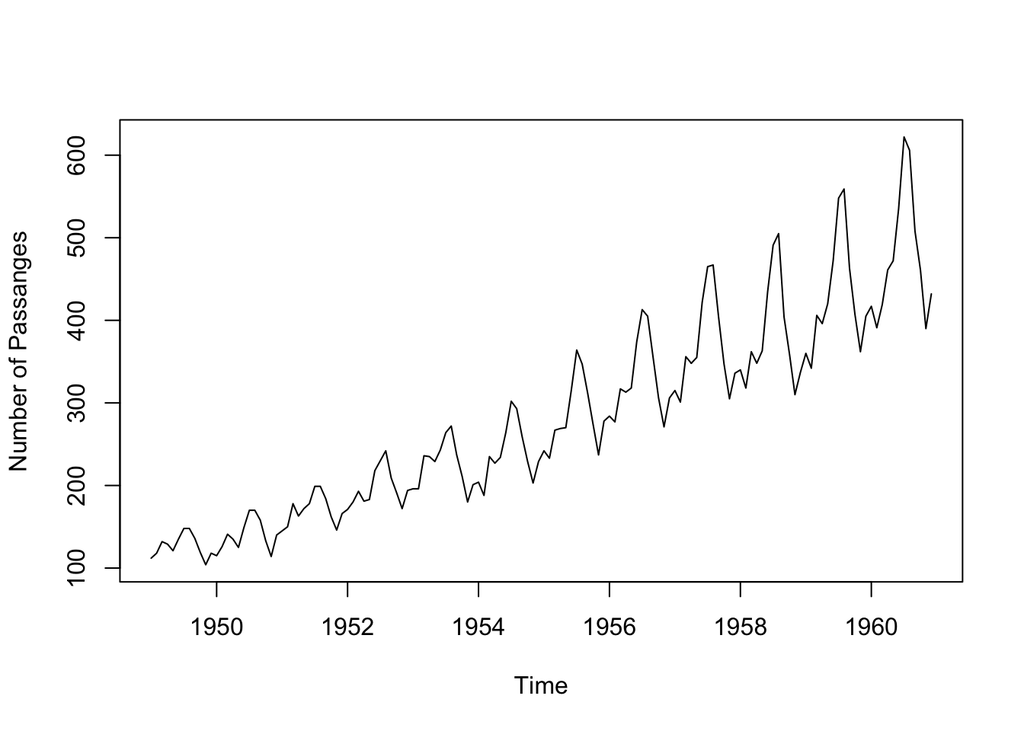

```r
plot(ap, ylab="Number of Passanges", xlab="Time")
```

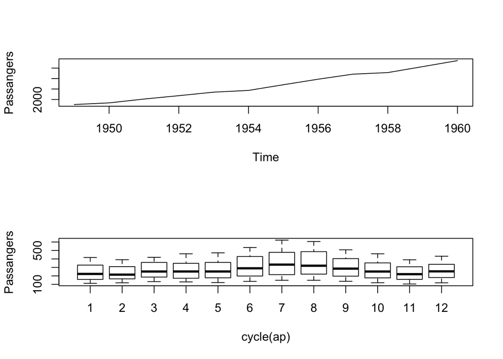

```r
# more
par(mfrow=c(2,1))
plot(aggregate(ap), ylab="Passangers") # 추세
boxplot(ap~cycle(ap), ylab="Passangers") # 월별분포
```

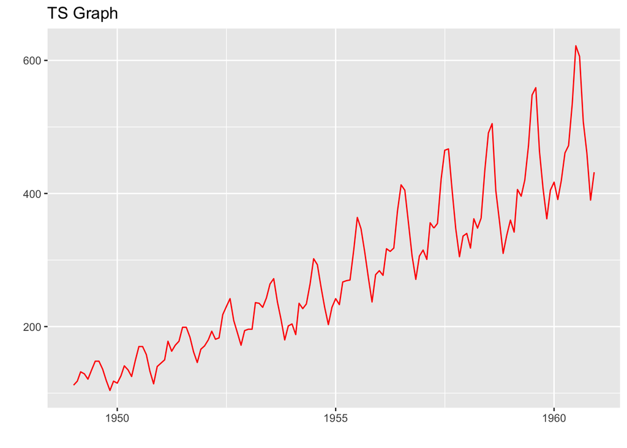

```r
# ggplot 사용 +  ggfortify있어야 autoplot을 사용할 수 있다.
autoplot(ap, ts.colour = 'red', main="TS Graph")
```

승객수는 년도마다 점점 늘어나는 추세이다. 그리고 월별로 승객수를보면 7~8월에 가장 많은 승객이 탑승하는 것을 알 수 있다.

- 다중시계열 다중시계열 plot기반의 추론: 여러개의 시계열을 다루는 경우가 많다. 시계열 간의 어떤 관계가 있는지 그래프를 통해 확인하는 것이 유용한 경우가 많다.

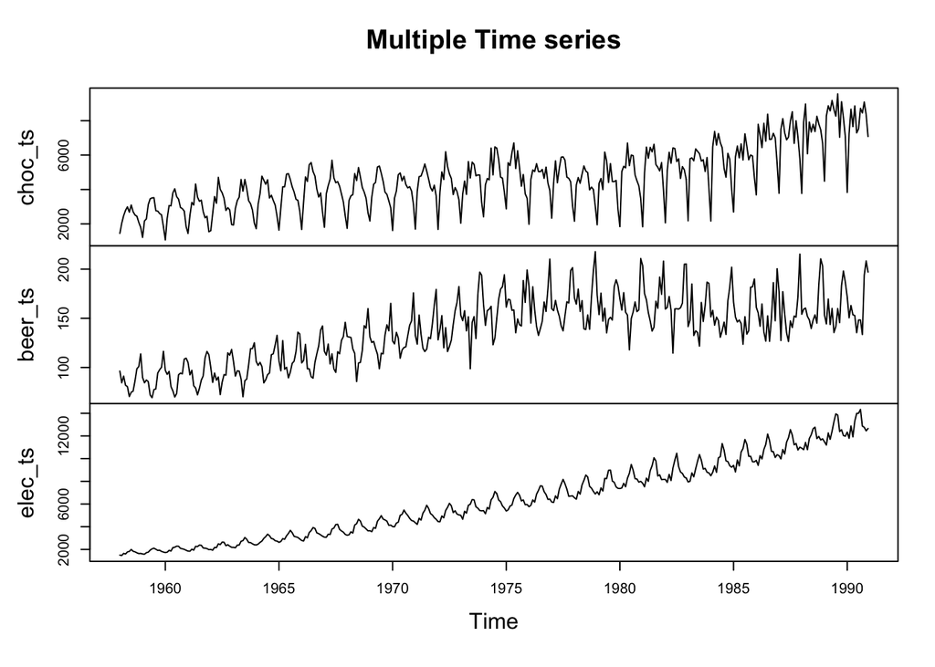

```r
cbe <- read.csv('./data/cbe.csv') # chocolate, beer, electic production
choc_ts <- ts(cbe[,1], start = 1958, frequency = 12)
beer_ts <- ts(cbe[,2], start = 1958, frequency = 12)
elec_ts <- ts(cbe[,3], start = 1958, frequency = 12)

plot(cbind(choc_ts, beer_ts, elec_ts), main="Multiple Time series")
```

```r
# 다중시계열 plot기반의 추론: 여러개의 시계열을 다루는 경우가 많다. 시계열 간의 어떤 관계가 있는지 그래프를 통해 확인하는 것이 유용한 경우가 많다.

# 기간이 다른 두 시계열을 어떻게 같이 고려할 수 있을까? : ts.intersect
ap_elec <- ts.intersect(ap, elec_ts)
str(ap_elec)
```

```
##  Time-Series [1:36, 1:2] from 1958 to 1961: 340 318 362 348 363 435 491 505 404 359 ...
##  - attr(*, "dimnames")=List of 2
##   ..$ : NULL
##   ..$ : chr [1:2] "ap" "elec_ts"
```

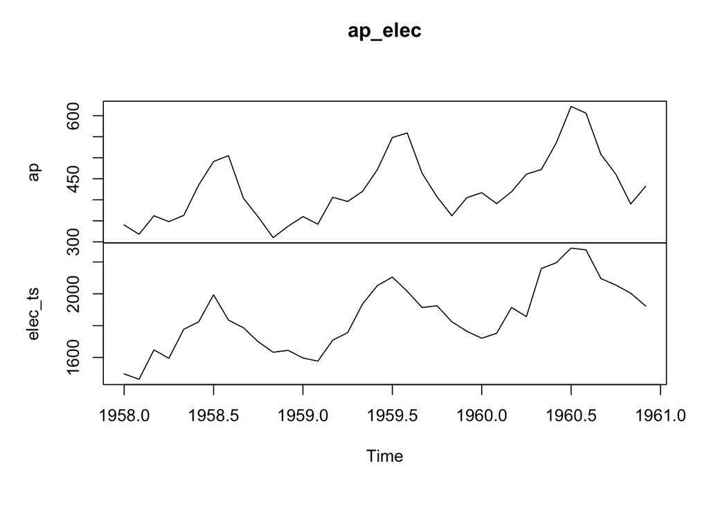

```r
plot(ap_elec)
```

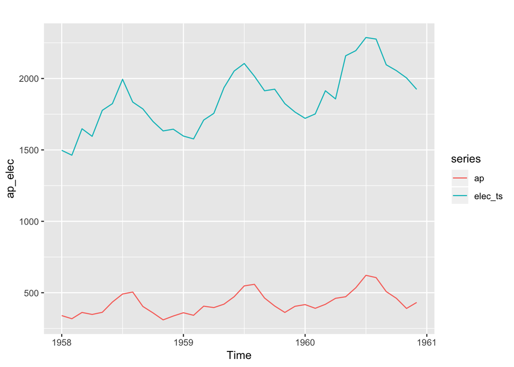

```r
autoplot(ap_elec)
```

# 시계열의 구성요소

1. 시계열의 구성요소
- 추세(trend): 계속 증가하거나, 감소하는 형태.
- 계절성(seasonality): 주기별로 반복되는 패턴을 의미.
2. 추세를 본다는 것은 계절성을 없애는 것을 의미: smoothing
3. 계절성을 볼 때는 추세를 제거하고 계절성을 분석.

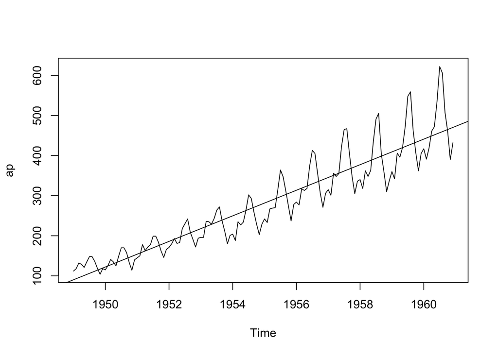

```r
# Trend plot
par(mfrow=c(1,1))
ap_time <- time(ap)
reg <- lm(ap~ap_time) # 회귀분석
plot(ap)
abline(reg)
```

4. 시계열의 분해: 트렌드와 계절성을 잘 설명할 수 있도록 계산해야함.
- 트렌드와 계절성 모두 있는 일반 시계열(원계열)
- 원계열에서 추세성을 제거하면 계절성만 남는다.
- 트렌드, 계절성으로 설명이 되지 않는 나머지 부분이 남는다 => 추가적 방법으로 분석이 필요

```r
decompose(ap)
```

```
## $x
##      Jan Feb Mar Apr May Jun Jul Aug Sep Oct Nov Dec
## 1949 112 118 132 129 121 135 148 148 136 119 104 118
## 1950 115 126 141 135 125 149 170 170 158 133 114 140
## 1951 145 150 178 163 172 178 199 199 184 162 146 166
## 1952 171 180 193 181 183 218 230 242 209 191 172 194
## 1953 196 196 236 235 229 243 264 272 237 211 180 201
## 1954 204 188 235 227 234 264 302 293 259 229 203 229
## 1955 242 233 267 269 270 315 364 347 312 274 237 278
## 1956 284 277 317 313 318 374 413 405 355 306 271 306
## 1957 315 301 356 348 355 422 465 467 404 347 305 336
## 1958 340 318 362 348 363 435 491 505 404 359 310 337
## 1959 360 342 406 396 420 472 548 559 463 407 362 405
## 1960 417 391 419 461 472 535 622 606 508 461 390 432
##
```

[output cut: 106 more lines]

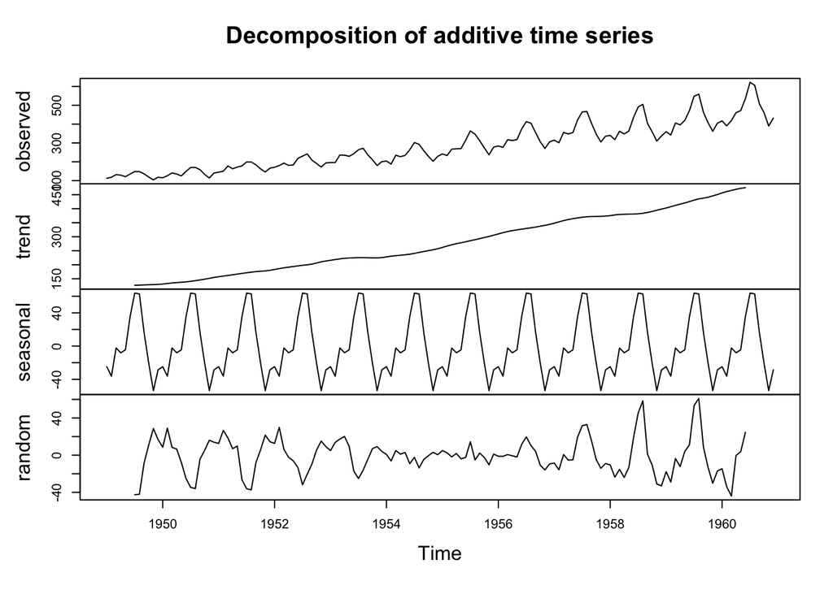

```r
plot(decompose(ap))
```